# Bellabeat - A case study

A. Chinonso

2024-02-29

## Bellabeat Case Study with R

**About the company:** Urška Sršen and Sando Mur founded Bellabeat, a high-tech company that manufactures health-focused smart products. Sršen used her background as an artist to develop beautifully designed technology that informs and inspires women around the world. Collecting data on activity, sleep, stress, and reproductive health has allowed Bellabeat to empowerwomen with knowledge about their own health and habits. Since it was founded in 2013, Bellabeat has grown rapidly and quickly positioned itself as a tech-driven wellness company for women.

### Phase 1

**Business task:**

- Identify trends in smart device usage
- Apply these trends to Bellabeat customers
- Explore how these trends can influence marketing strategy

**The key stakeholders** of this study are Urška Sršen, Bellabeat’s co-founder and Chief Creative Officer; Sando Mur, Mathematician and Bellabeat’s cofounder; And the rest of the Bellabeat marketing analytics team.

### Phase 2

License CC0: Public Domain

To see the dataset, click here [Link to dataset](https://www.kaggle.com/code/thefitgeek/bellabeat-smart-device-case-study?scriptVersionId=163010850&cellId=11)

### Phase 3

Preparing our R environment

```r
install.packages("janitor")
install.packages("tidyverse")
install.packages("skimr")
install.packages("lubridate")
library(tidyverse)
library(skimr)
library(janitor)
library(lubridate)
```

Now, we’ll import our datasets

```r
Activity <- read.csv("cs/Fitabase Data 4.12.16-5.12.16/dailyActivity_merged.csv")
Calories <- read.csv("cs/Fitabase Data 4.12.16-5.12.16/dailyCalories_merged.csv")
Intensities <- read.csv("cs/Fitabase Data 4.12.16-5.12.16/dailyIntensities_merged.csv")
Steps <- read.csv("cs/Fitabase Data 4.12.16-5.12.16/dailySteps_merged.csv")
SleepDay <- read.csv("cs/Fitabase Data 4.12.16-5.12.16/sleepDay_merged.csv")
Weight <- read.csv("cs/Fitabase Data 4.12.16-5.12.16/weightLogInfo_merged.csv")
```

Then we inspect our imported files for errors and mistakes during the process.

```r
head(Activity)
```

```
##           Id ActivityDate TotalSteps TotalDistance TrackerDistance
## 1 1503960366    4/12/2016      13162          8.50            8.50
## 2 1503960366    4/13/2016      10735          6.97            6.97
## 3 1503960366    4/14/2016      10460          6.74            6.74
## 4 1503960366    4/15/2016       9762          6.28            6.28
## 5 1503960366    4/16/2016      12669          8.16            8.16
## 6 1503960366    4/17/2016       9705          6.48            6.48
##   LoggedActivitiesDistance VeryActiveDistance ModeratelyActiveDistance
## 1                        0               1.88                     0.55
## 2                        0               1.57                     0.69
## 3                        0               2.44                     0.40
## 4                        0               2.14                     1.26
## 5                        0               2.71                     0.41
## 6                        0               3.19                     0.78
##   LightActiveDistance SedentaryActiveDistance VeryActiveMinutes
## 1                6.06                       0                25
## 2                4.71                       0                21
## 3                3.91                       0                30
## 4                2.83                       0                29
## 5                5.04                       0                36
## 6                2.51                       0                38
##   FairlyActiveMinutes LightlyActiveMinutes SedentaryMinutes Calories
## 1                  13                  328              728     1985
## 2                  19                  217              776     1797
## 3                  11                  181             1218     1776
## 4                  34                  209              726     1745
## 5                  10                  221              773     1863
## 6                  20                  164              539     1728
```

```r
head(Calories)
```

```
##           Id ActivityDay Calories
## 1 1503960366   4/12/2016     1985
## 2 1503960366   4/13/2016     1797
## 3 1503960366   4/14/2016     1776
## 4 1503960366   4/15/2016     1745
## 5 1503960366   4/16/2016     1863
## 6 1503960366   4/17/2016     1728
```

```r
head(Intensities)
```

```
##           Id ActivityDay SedentaryMinutes LightlyActiveMinutes
## 1 1503960366   4/12/2016              728                  328
## 2 1503960366   4/13/2016              776                  217
## 3 1503960366   4/14/2016             1218                  181
## 4 1503960366   4/15/2016              726                  209
## 5 1503960366   4/16/2016              773                  221
## 6 1503960366   4/17/2016              539                  164
##   FairlyActiveMinutes VeryActiveMinutes SedentaryActiveDistance
## 1                  13                25                       0
## 2                  19                21                       0
## 3                  11                30                       0
## 4                  34                29                       0
## 5                  10                36                       0
## 6                  20                38                       0
##   LightActiveDistance ModeratelyActiveDistance VeryActiveDistance
## 1                6.06                     0.55               1.88
## 2                4.71                     0.69               1.57
## 3                3.91                     0.40               2.44
## 4                2.83                     1.26               2.14
## 5                5.04                     0.41               2.71
## 6                2.51                     0.78               3.19
```

```r
head(SleepDay)
```

```
##           Id              SleepDay TotalSleepRecords TotalMinutesAsleep
## 1 1503960366 4/12/2016 12:00:00 AM                 1                327
## 2 1503960366 4/13/2016 12:00:00 AM                 2                384
## 3 1503960366 4/15/2016 12:00:00 AM                 1                412
## 4 1503960366 4/16/2016 12:00:00 AM                 2                340
## 5 1503960366 4/17/2016 12:00:00 AM                 1                700
## 6 1503960366 4/19/2016 12:00:00 AM                 1                304
##   TotalTimeInBed
## 1            346
## 2            407
## 3            442
## 4            367
## 5            712
## 6            320
```

```r
head(Steps)
```

```
##           Id ActivityDay StepTotal
## 1 1503960366   4/12/2016     13162
## 2 1503960366   4/13/2016     10735
## 3 1503960366   4/14/2016     10460
## 4 1503960366   4/15/2016      9762
## 5 1503960366   4/16/2016     12669
## 6 1503960366   4/17/2016      9705
```

```r
head(Weight)
```

```
##           Id                  Date WeightKg WeightPounds Fat   BMI
## 1 1503960366  5/2/2016 11:59:59 PM     52.6     115.9631  22 22.65
## 2 1503960366  5/3/2016 11:59:59 PM     52.6     115.9631  NA 22.65
## 3 1927972279  4/13/2016 1:08:52 AM    133.5     294.3171  NA 47.54
## 4 2873212765 4/21/2016 11:59:59 PM     56.7     125.0021  NA 21.45
## 5 2873212765 5/12/2016 11:59:59 PM     57.3     126.3249  NA 21.69
## 6 4319703577 4/17/2016 11:59:59 PM     72.4     159.6147  25 27.45
##   IsManualReport        LogId
## 1           True 1.462234e+12
## 2           True 1.462320e+12
## 3          False 1.460510e+12
## 4           True 1.461283e+12
## 5           True 1.463098e+12
## 6           True 1.460938e+12
```

Using the separate() function, we separate the SleepDay column from the SleepDay data frame.

```r
Sleep <- SleepDay %>%
   separate(SleepDay, c("Date", "Time"), " ")
head(Sleep)
```

```
##           Id      Date     Time TotalSleepRecords TotalMinutesAsleep
## 1 1503960366 4/12/2016 12:00:00                 1                327
## 2 1503960366 4/13/2016 12:00:00                 2                384
## 3 1503960366 4/15/2016 12:00:00                 1                412
## 4 1503960366 4/16/2016 12:00:00                 2                340
## 5 1503960366 4/17/2016 12:00:00                 1                700
## 6 1503960366 4/19/2016 12:00:00                 1                304
##   TotalTimeInBed
## 1            346
## 2            407
## 3            442
## 4            367
## 5            712
## 6            320
```

Now, we determine the number of respondents in each data frame by counting the number of distinct Ids.

```r
n_distinct(Sleep$Id)
```

```
## [1] 24
```

```r
n_distinct(Activity$Id)
```

```
## [1] 33
```

```r
n_distinct(Calories$Id)
```

```
## [1] 33
```

```r
n_distinct(Intensities$Id)
```

```
## [1] 33
```

```r
n_distinct(Weight$Id)
```

```
## [1] 8
```

```r
n_distinct(Steps$Id)
```

```
## [1] 33
```

We have 33 respondents for the Activity, Calories, Intensities, Steps data frames. And 24 and 8 respondents for the Sleep and Weight data frames respectively. Now, the weight data frame has too small a sample size for analysis on it to carry weight*. That said, we would focus most of the effort of this study on the other data frames.

### Phase 4

Firstly, we explore the summary statistics of these data frames.

```r
Activity %>%
   select(TotalSteps,
          TotalDistance,
          VeryActiveMinutes,
          FairlyActiveMinutes,
          LightlyActiveMinutes,
          SedentaryMinutes,
          Calories) %>%
  summary()
```

```
##    TotalSteps    TotalDistance    VeryActiveMinutes FairlyActiveMinutes
##  Min.   :    0   Min.   : 0.000   Min.   :  0.00    Min.   :  0.00
##  1st Qu.: 3790   1st Qu.: 2.620   1st Qu.:  0.00    1st Qu.:  0.00
##  Median : 7406   Median : 5.245   Median :  4.00    Median :  6.00
##  Mean   : 7638   Mean   : 5.490   Mean   : 21.16    Mean   : 13.56
##  3rd Qu.:10727   3rd Qu.: 7.713   3rd Qu.: 32.00    3rd Qu.: 19.00
##  Max.   :36019   Max.   :28.030   Max.   :210.00    Max.   :143.00
##  LightlyActiveMinutes SedentaryMinutes    Calories
##  Min.   :  0.0        Min.   :   0.0   Min.   :   0
##  1st Qu.:127.0        1st Qu.: 729.8   1st Qu.:1828
##  Median :199.0        Median :1057.5   Median :2134
##  Mean   :192.8        Mean   : 991.2   Mean   :2304
##  3rd Qu.:264.0        3rd Qu.:1229.5   3rd Qu.:2793
##  Max.   :518.0        Max.   :1440.0   Max.   :4900
```

```r
Weight %>%
   select(WeightKg, BMI) %>%
   summary()
```

```
##     WeightKg           BMI
##  Min.   : 52.60   Min.   :21.45
##  1st Qu.: 61.40   1st Qu.:23.96
##  Median : 62.50   Median :24.39
##  Mean   : 72.04   Mean   :25.19
##  3rd Qu.: 85.05   3rd Qu.:25.56
##  Max.   :133.50   Max.   :47.54
```

```r
Sleep %>%
   select(TotalSleepRecords,
          TotalMinutesAsleep,
          TotalTimeInBed) %>%
   summary()
```

```
##  TotalSleepRecords TotalMinutesAsleep TotalTimeInBed
##  Min.   :1.000     Min.   : 58.0      Min.   : 61.0
##  1st Qu.:1.000     1st Qu.:361.0      1st Qu.:403.0
##  Median :1.000     Median :433.0      Median :463.0
##  Mean   :1.119     Mean   :419.5      Mean   :458.6
##  3rd Qu.:1.000     3rd Qu.:490.0      3rd Qu.:526.0
##  Max.   :3.000     Max.   :796.0      Max.   :961.0
```

### Phase 5

We’ll merge the data frames first to allow for easy visualization.

```r
names(Activity)[2] <- 'Date'
```

```r
Updated <- merge(Activity, Sleep, by = c('Id', 'Date'))
head(Updated)
```

```
##           Id      Date TotalSteps TotalDistance TrackerDistance
## 1 1503960366 4/12/2016      13162          8.50            8.50
## 2 1503960366 4/13/2016      10735          6.97            6.97
## 3 1503960366 4/15/2016       9762          6.28            6.28
## 4 1503960366 4/16/2016      12669          8.16            8.16
## 5 1503960366 4/17/2016       9705          6.48            6.48
## 6 1503960366 4/19/2016      15506          9.88            9.88
##   LoggedActivitiesDistance VeryActiveDistance ModeratelyActiveDistance
## 1                        0               1.88                     0.55
## 2                        0               1.57                     0.69
## 3                        0               2.14                     1.26
## 4                        0               2.71                     0.41
## 5                        0               3.19                     0.78
## 6                        0               3.53                     1.32
##   LightActiveDistance SedentaryActiveDistance VeryActiveMinutes
```

[output cut: 20 more lines]

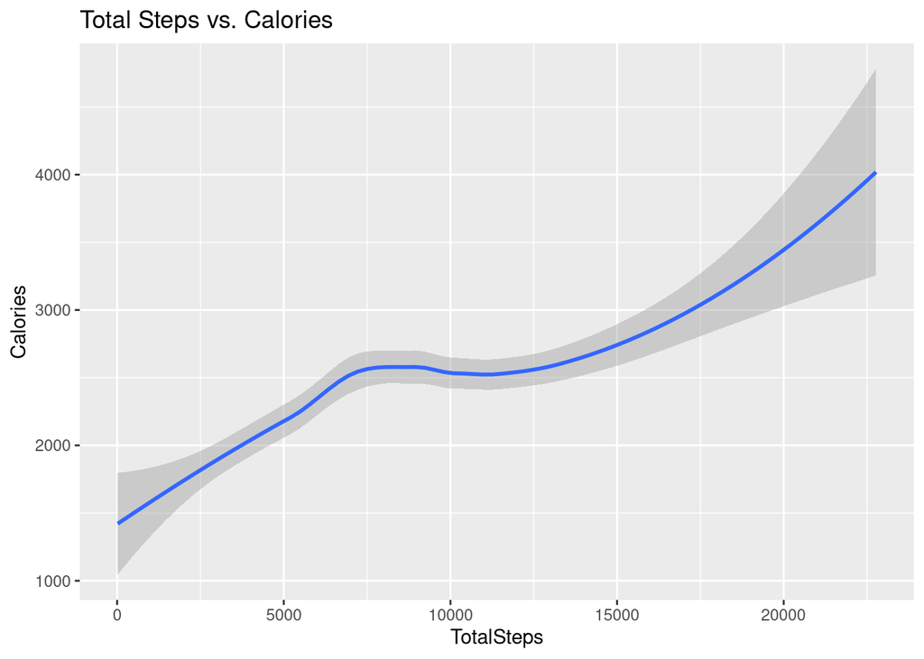

```r
ggplot(data=Updated, aes(x=TotalSteps, y=Calories)) +
   geom_smooth() + labs(title="Total Steps vs. Calories")
```

From this viz, we see that there is a positive relationship between total steps and calories. This means that the more steps taken the more calories burnt.

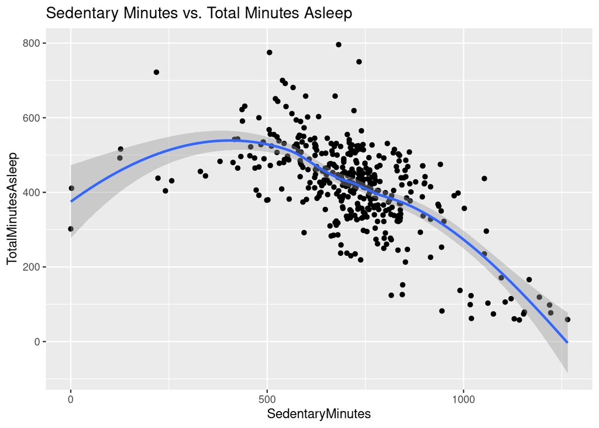

```r
ggplot(data=Updated, aes(x=SedentaryMinutes, y=TotalMinutesAsleep)) +
   geom_point() + geom_smooth() + labs(title="Sedentary Minutes vs. Total Minutes Asleep")
```

Here we see that the respondents with the most sedentary minutes experienced less sleep time than respondents that spent less time sedentary.

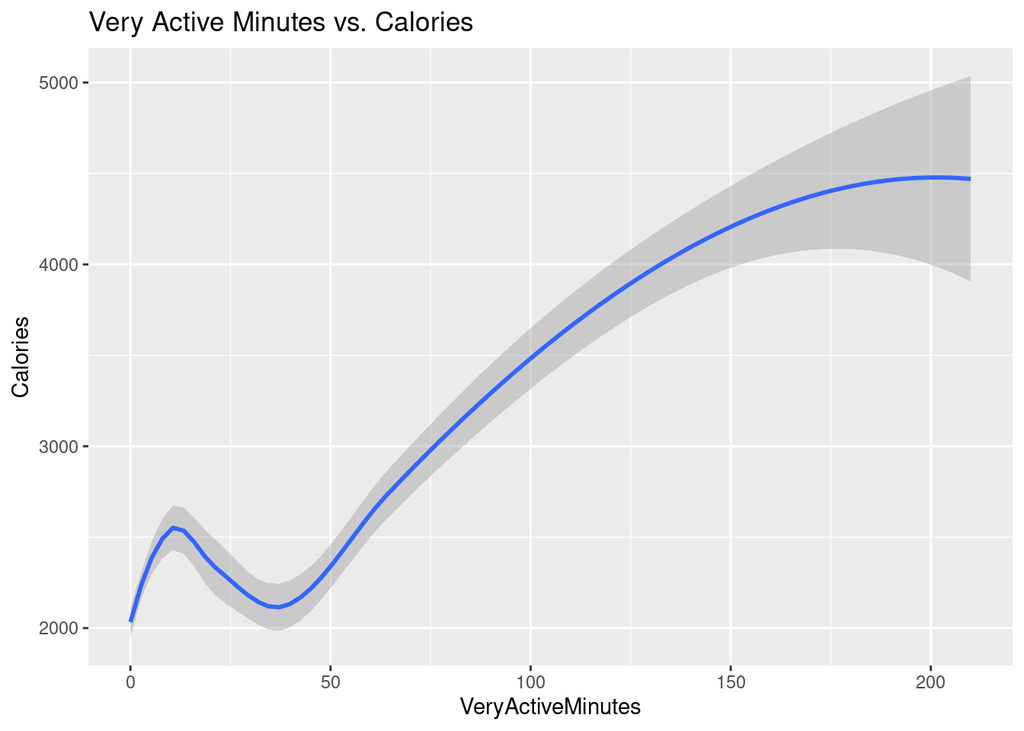

```r
ggplot(data=Updated, aes(x=VeryActiveMinutes, y=Calories)) +
  geom_smooth() + labs(title="Very Active Minutes vs. Calories")
```

### Phase 6

**Top high-level insights**

- We could include notifications in our app that:
  - Notifies our clients to when they have spent a lot of time in sedentary positions.
  - Reminds our clients the benefit of time spent active in relation to calories burnt and sleep quality.
- We could also advertise to people, especially those who lead very sedentary lifestyles, showing them how our products can help better their health and sleep quality.

*Thank you!*